# Basecalling function for Illumina BCL

# 3 Style macros

*BiocStyle* introduces the following macros useful when referring to *R* packages:

- `` `r Biocpkg("IRanges")` `` for *Bioconductor* software, annotation and experiment data packages, including a link to the release landing page or if the package is only in devel, to the devel landing page, *IRanges*.
- `` `r CRANpkg("data.table")` `` for *R* packages available on CRAN, including a link to the FHCRC CRAN mirror landing page, *[data.table](http://cran.fhcrc.org/web/packages/data.table/index.html)*.
- `` `r Githubpkg("rstudio/rmarkdown")` `` for *R* packages available on GitHub, including a link to the package repository, *rmarkdown*.
- `` `r Rpackage("MyPkg")` `` for *R* packages that are *not* available on *Bioconductor*, CRAN or GitHub; *MyPkg*.

# 4 Additional formatting features

Compared to the default markdown appearance the formatting differences include:

- Images and tables appear centered, e.g.

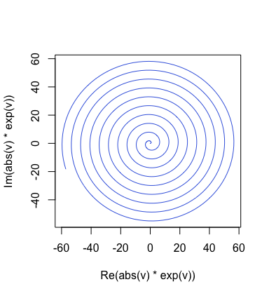

  ```r
  v = seq(0, 60i, length = 1000)
  plot(abs(v)*exp(v), type = "l", col = "Royalblue")
  ```

- Tables are displayed with striped rows:

  ```markdown
  Fruit   | Price
  ------- | -----
  bananas | 1.2
  apples  | 1.0
  oranges | 2.5
  ```

  produces

  | Fruit | Price |
  | --- | --- |
  | bananas | 1.2 |
  | apples | 1.0 |
  | oranges | 2.5 |

- Paragraph text is justified
- External links open in new browser tab/window

Math symbols can be included in markdown documents. You can write math expressions the same way you would in `Latex`, except some differences in escaping them.

- Inline: For inline formulas use `$P(x) = \frac{1}{2}$` or `\(P(x) = \frac{1}{2}\)`, which both render as $P(x) = \frac{1}{2}$.
- Standalone: Math can be displayed in a separate line by writing `$$P(x) = \frac{1}{2}$$` or `\[P(x) = \frac{1}{2}.\]`, which both result in
  $$P(x) = \frac{1}{2}.$$

# 5 Session info

Here is the output of `sessionInfo()` on the system on which this document was compiled:

```
## R Under development (unstable) (2016-03-11 r70310)
## Platform: x86_64-apple-darwin13.4.0 (64-bit)
## Running under: OS X 10.11 (El Capitan)
##
## locale:
## [1] C/en_GB.UTF-8/en_GB.UTF-8/C/en_GB.UTF-8/en_GB.UTF-8
##
## attached base packages:
## [1] stats     graphics  grDevices utils     datasets  methods   base
##
## other attached packages:
##  [1] dplyr_0.5.0        BiocStyle_2.0.3    basecallQC_0.1.1
##  [4] raster_2.5-8       sp_1.2-3           RColorBrewer_1.1-2
##  [7] XML_3.98-1.4       stringr_1.1.0      yaml_2.1.14
## [10] knitr_1.13         rmarkdown_1.0      ggplot2_2.2.0
## [13] testthat_1.0.2
##
## loaded via a namespace (and not attached):
##  [1] Rcpp_0.12.8      formatR_1.4      plyr_1.8.4       tools_3.3.0
##  [5] digest_0.6.10    evaluate_0.9     memoise_1.0.0    tibble_1.2
##  [9] gtable_0.2.0     lattice_0.20-33  DBI_0.4-1        commonmark_1.2
## [13] withr_1.0.2      roxygen2_6.0.1   xml2_1.0.0       desc_1.1.0
## [17] devtools_1.12.0  rprojroot_1.2    grid_3.3.0       R6_2.1.2
## [21] tidyr_0.6.0      magrittr_1.5     scales_0.4.1     backports_1.0.3
## [25] htmltools_0.3.5  assertthat_0.1   colorspace_1.2-6 stringi_1.1.1
## [29] lazyeval_0.2.0   munsell_0.4.3    crayon_1.3.2
```